# Homework1_Question1

Hannah Zmuda

# Question 1

The goal of this problem is to find the inverse CDF of the given density:

$$f_X(x) = exp(x - e^x)$$

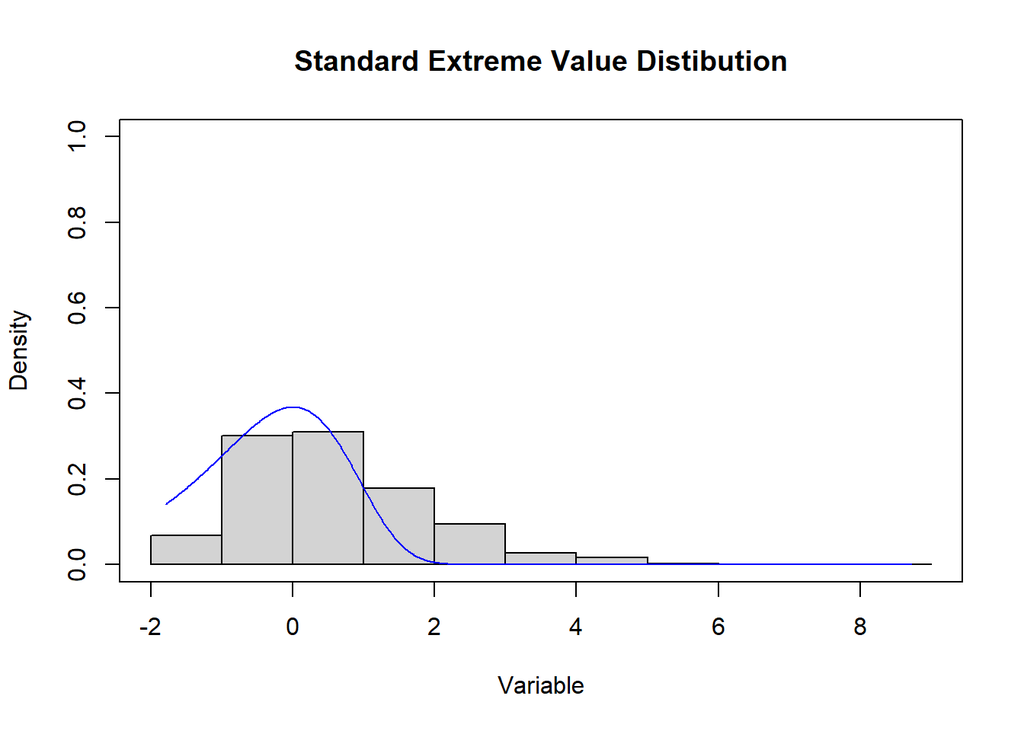

```r
n <- 1000 #sample number
U1 <- runif(n,0,1) #Random Number Generator, numbers are evenly distributed between 0 and 1
f <- function(x){exp(x - exp(x))}#the standard extreme value distribution density function
q <- function(U1){-log(-log(U1))}#inverse of the standard extreme value distribution density function, run uniform data through (U1)
#histogram of simulated data
hist(q(U1), prob = TRUE, main = "Standard Extreme Value Distibution", ylim = c(0, 1), xlab = "Variable", ylab ="Density")
x <- seq(min(q(U1)), max(q(U1)), 0.01)
lines(x,f(x), col = "blue") #density curve of f(x)

box()
```

# Question 2

The objective of question 2 is to develop an algorithm to simulate the Rayleigh distribution. This will be in the form of a function with two inputs: the sample size as n and the scale parameter as $\sigma$. The Rayleigh distribution has a density of;
$$f(x) = \frac{x}{\sigma^2}exp(-\frac{x^2}{2\sigma^2})$$
Integrating density:
$$F_x(x) = -exp(-\frac{x^2}{2\sigma^2})$$
Inverse of the CDF (of the given density function) is:
$$F^{-1}(x,\sigma) = \sigma\sqrt{-2ln(1 - x)}$$

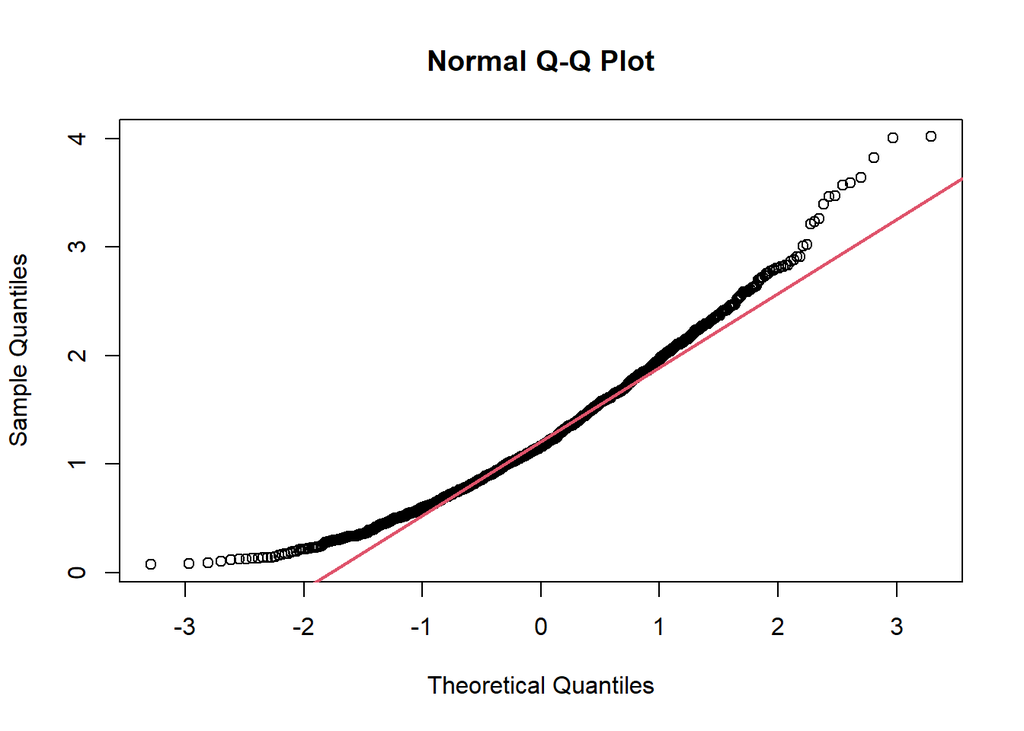

```r
#Inverse CDF approach for the Rayleigh distribution
r <- function(n,s){
  U2 <- runif(n,0,1)
  x <- s*sqrt(-2*log(1-U2))
  return(x)
}
#Check normality
qqnorm(r(1000,1))
qqline(r(1000,1),lwd=2,col=2)
```

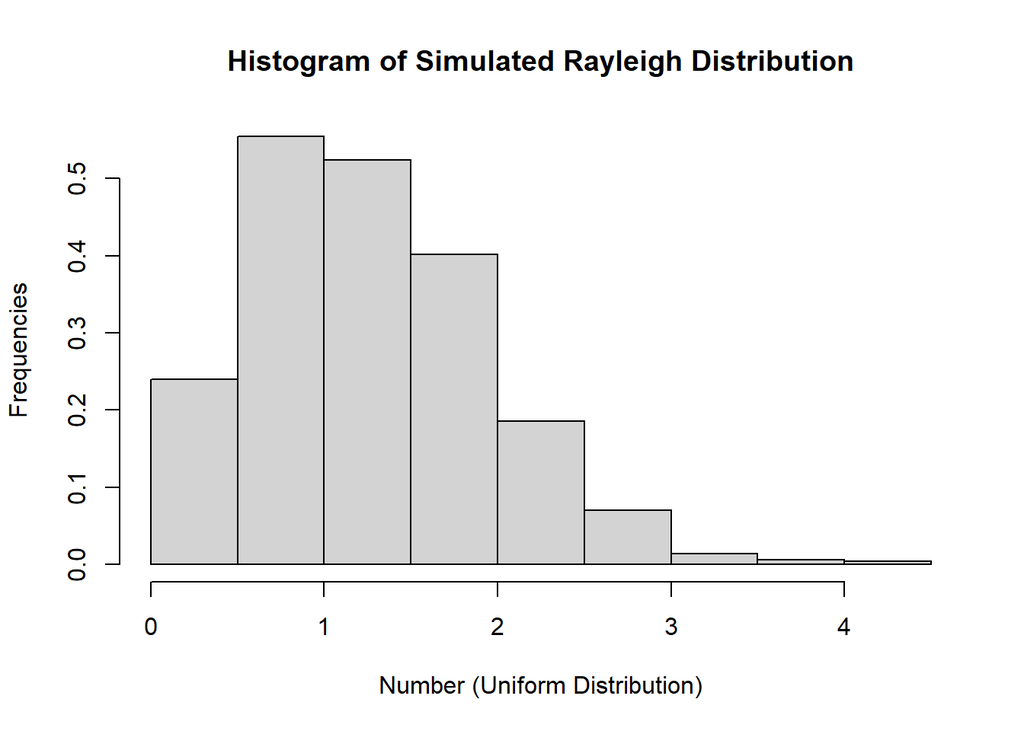

```r
#Histogram of simulated data
hist(r(1000,1), prob = TRUE,xlab = "Number (Uniform Distribution)",ylab = "Frequencies",main = "Histogram of Simulated Rayleigh Distribution")
```

```r
#
```

# Question 3

When using Bayesian Inference, we sometimes simulate the prior, $\theta$, and maximize it to ensure we are maximizing the mean of the distribution. This can be done by accepting $\theta$ as $u \le \frac{f(x|\theta)}{f(x|\hat{\theta})}$ where $u ~ U(0,1)$ and $\hat{\theta}$ is the MLE from maximizing $f(x|\theta)$.

We can do this by saying that $\frac{f(x|\theta)}{f(x|\hat{\theta})}$ is a constant equal to $M$ such that $M$ maximizes the posterior density, $f(\theta|x)$. Using the Acceptance-Rejection Method, we can find the simulate and maximize the prior. This has been described as choosing a simpler distribution function, $g(x)$, that is proportional to the distribution of the pdf $f(x)$, such that $f(x) \le cg(x)$ where c is a constant. It is important to note that $g(x)$ must be carefully chosen to make sure there are not too many iterations of the algorithm and that $g(x)$ can envelop $f(x)$. One good distribution is the gamma distribution, though it cannot fully envelop a Gaussian curve, it will have fewer iterations compared to other distributions [1](https://statistics.stanford.edu/sites/g/files/sbiybj6031/f/CHE%20ONR%2083.pdf).